# Introduction to DrugScreenExplorer

Junyan Lu

June 19, 2025

# 1 Introduction

*DrugScreenExplorer* is an R package designed for streamlined processing, quality control and visualizing of high-throughput drug sensitivity screen data.

The package can achieve the following functions:

1, data preprocessing; 2, check and report the quality of the screen data;  
1, normalize the viability values;  
2, detect and adjust the edge effects  
3, summarize drug effects using several measures, e.g., IC50 and AUC  
4, summarize the synergy or antagonism effects of two-drug combination  
6, using a shiny app to explore process data interactively

*DrugScreenExplorer* was original designed to proceed the single drug screening, but now extended to two-drug combinations.

```r
library(DrugScreenExplorer)
library(tidyr)
library(dplyr)
library(gridExtra)
library(ggplot2)
library(tools)
```

# 2 Installation

The *DrugScreenExplorer* package can be installed from Bioconductor using the following commands:

```r
if (!requireNamespace("BiocManager", quietly = TRUE)) install.packages("BiocManager")
BiocManager::install("DrugScreenExplorer")
```

# 3 Data import

## 3.1 Introduction of input file types

For creating the complete drug screen datasets, three types of data are needed:

1. the raw screening data in text format, which stores the values out from a plate reader;
2. the well annotation or plate layout, which stores the metadata for all the wells on a screening plate. The most important annotations are drug names and concentrations;
3. the plate annotation, which stores the metadata for each plate. For example, the sample information, if each plate represents one sample.

The examples for each type of the input files can be found in the test data affiliated with this package:

**Raw screening data**

```r
system.file("testData/rawData", package = "DrugScreenExplorer")
```

```
#> [1] "C:/Users/wangs/AppData/Local/R/win-library/4.4/DrugScreenExplorer/testData/rawData"
```

If the text files containing the raw screening data are organized by subfolders, the subfolders will be considered as batches.

**Plate annotation file**

```r
system.file("testData/plateAnno/plateAnno.tsv", package = "DrugScreenExplorer")
```

```
#> [1] "C:/Users/wangs/AppData/Local/R/win-library/4.4/DrugScreenExplorer/testData/plateAnno/plateAnno.tsv"
```

The *fileName* column is mandatory. If the plates do not all have the same layout, for example, several plates are used for the same sample but with different drug collections, a *plateID* column can be included to indicate the plate index.

**Well annotation file**

```r
system.file("testData/wellAnno/wellAnno.tsv", package = "DrugScreenExplorer")
```

```
#> [1] "C:/Users/wangs/AppData/Local/R/win-library/4.4/DrugScreenExplorer/testData/wellAnno/wellAnno.tsv"
```

The *wellID* column is mandatory. If plates have different layouts, a *plateID* column can be used as in the plate annotation file.

## 3.2 Functions for creating annotation files

Besides create the well and plate annotations files manually, there are two functions can be used to help create the annotation input files.

### 3.2.1 createPlateInput()

The function creates a framework for the plate annotation input based on the raw data files and folder structure in the raw data folder.

```r
rawFolder <- system.file("testData/rawData", package = "DrugScreenExplorer")
```

```r
createPlateInput(rawDir = rawFolder, file = "plateAnno.csv", entries = c("sampleID",
    "patientID"))
plateAnno <- read.csv("./plateAnno.csv", sep = "\t")
head(plateAnno)
```

```
#>                             fileName sampleID patientID
#> 1                 P0007_12PB0265.txt       NA        NA
#> 2                 P0010_11PB0010.txt       NA        NA
#> 3                 P0019_11PB0021.txt       NA        NA
#> 4                 P0021_11PB0023.txt       NA        NA
#> 5 CTGLuminescence_P0007_12PB0265.txt       NA        NA
#> 6 CTGLuminescence_P0007_14PB0491.txt       NA        NA
```

An csv file named “plateAnno.csv” will be created and it has three columns: *fileName*, *sampleID*, and *patientID*. The *fileName* column is automatically filled based on the files in the raw data folder, while *sampleID* and *patientID* columns need to be filled manually in the created “plateAnno.csv”.

When raw data is saved within sub-folders, each sub-folder representing data from distinct batches, the *createPlateInput()* function can search for the raw data within each sub-folder and automatically generate batch information when *batchAsFolder* is set to *TRUE*.

```r
rawFolder <- system.file("testData/rawData", package = "DrugScreenExplorer")
createPlateInput(rawDir = rawFolder, file = "plateAnno.csv", entries = c("sampleID",
    "patientID"), batchAsFolder = TRUE)

plateAnno <- read.csv("./plateAnno.csv", sep = "\t")
head(plateAnno)
```

In the output *plateAnno.csv* file, there’s an additional column *batch*, which contains the batch information. Notice that the folder names are not used as batch names. Instead, the series of integer numbers will be assigned to batches based on the ordering of the folder names.

### 3.2.2 createWellInput()

The function creates the framework for the well annotation input.

```r
createWellInput(file = "wellAnno.csv", colNum = 24, rowNum = 16, entries = c("drug",
    "concentration"))

wellAnno <- read.csv("wellAnno.csv", sep = "\t")
head(wellAnno)
```

A *wellAnno.csv* file will be created for a 384-well (16*24) plate. The *wellID* is automatically filled by the *drug* and *concentration* columns need to be filled manual.

If more than one plate layouts for a sample are used in the screen, for example, when one plate is not enough for testing all the drugs, the *platePerSample* parameter can be used to specify how many different plate layouts are used for each sample.

```r
createWellInput(file = "wellAnno.csv", colNum = 24, rowNum = 16, entries = c("name",
    "concentration"), platePerSample = 2)
```

In the *wellAnno.csv* file, an additional column *plateID* will be created, indicating the index of the plate layout type. It is important that a *plateID* column must also be created manually in the plate annotation file, to specify which plate layout a certain plate is using.

## 3.3 Read in the whole experiment

After preparing the raw data folder, the plate annotation file and the well annotation file, the whole experiment can be read in using the `readScreen()` function.

```r
plateFile <- system.file("testData/plateAnno/plateAnno.tsv", package = "DrugScreenExplorer")

wellFile <- system.file("testData/wellAnno/wellAnno.tsv", package = "DrugScreenExplorer")

screenData <- readScreen(rawDir = rawFolder, plateAnnotationFile = plateFile,
    wellAnnotationFile = wellFile, rowRange = c(3, 18), colRange = 2, sep = "[;\t]",
    negWell <- c("DMSO", "PBS"), posWell = c())
head(screenData)
```

```
#> # A tibble: 6 × 14
#>   wellID rowID colID   value fileName       batch sampleID patientID Mutation Expression Group drug
#>   <chr>  <chr> <chr>   <dbl> <chr>          <fct> <chr>    <chr>        <dbl>      <dbl> <chr> <chr>
#> 1 A001   A0    01    1083480 CTGLuminescen… 1     11PB0010 P0010            0        1.1 A     DMSO
#> 2 A002   A0    02     856480 CTGLuminescen… 1     11PB0010 P0010            0        1.1 A     DMSO
#> 3 A003   A0    03    1014920 CTGLuminescen… 1     11PB0010 P0010            0        1.1 A     A-12…
#> 4 A004   A0    04      21000 CTGLuminescen… 1     11PB0010 P0010            0        1.1 A     Afat…
#> 5 A005   A0    05    1151520 CTGLuminescen… 1     11PB0010 P0010            0        1.1 A     A-12…
#> 6 A006   A0    06     557760 CTGLuminescen… 1     11PB0010 P0010            0        1.1 A     Afat…
#> # ℹ 2 more variables: concentration <dbl>, wellType <chr>
```

A tidy table containing the drug screening result and metadata will be created.

The raw data format may vary across different platforms. *readScreen()* provides two arguments *rowRange* and *colRange* specifying the staring and ending positions of the numeric data that represent signals. For instance, *rowRange = c(3, 18)* and *colRange = 2* indicate that the data spans rows 3 to 18 and columns 2 to the last column, containing the signal information. Argument *sep* can specify delimiters (e.g, “,” or “[;”), where regular expression is supported.

The positive control and negative control wells can be defined in *negWell* and *posWell*. The input for *negWell* or *posWell* can be either a character vector of *wellIDs* or drug names if the *drug* column is given in the well annotation file. Wells that are not labeled as positive controls (“pos”) or negative controls (“neg”) will be labelled as “sample” in the “wellType” column of the final output table. This column is important for plate-wise normalization.

The inhibition rate for each well can also be calculated at this stage by specifying “normalization = TRUE”. Currently, two methods are supported: “negatives” and “NPI”. The “negative” method calculates the inhibition rate by dividing each measurement by the median of negative controls on the same plate $x_{normalized} = \frac{x}{Median(x_{neg})}$, where $Median(x_{neg})$ represents the median of negative controls; The “NPI” method, which stands for “normalized percent inhibition”, measures the distance to the positive controls against the distance between the negative control and positive controls, calculated as $x_{normalized} = \frac{x - Median(x_{pos})}{Median(x_{neg}) - Median(x_{pos})}$.

```r
screenData <- readScreen(rawDir = rawFolder, plateAnnotationFile = plateFile,
    wellAnnotationFile = wellFile, rowRange = c(3, 18), colRange = 2, sep = "[;\t]",
    negWell <- c("DMSO", "PBS"), posWell = c(), normalization = TRUE, method = "negatives",
    discardLayer = 2)
head(screenData %>%
    dplyr::select(wellID, value, sampleID, drug, concentration, wellType, normVal))
```

```
#> # A tibble: 6 × 7
#>   wellID  value sampleID drug      concentration wellType normVal
#>   <chr>   <dbl> <chr>    <chr>             <dbl> <chr>      <dbl>
#> 1 A001   507840 12PB0265 DMSO                0.3 neg       1.14
#> 2 A002   569760 12PB0265 DMSO                0.3 neg       1.28
#> 3 A003   487880 12PB0265 A-1210477          10   sample    1.09
#> 4 A004    13400 12PB0265 Afatinib           10   sample    0.0301
#> 5 A005   528920 12PB0265 A-1210477           2   sample    1.19
#> 6 A006   244640 12PB0265 Afatinib            2   sample    0.549
```

With “normalization = TRUE”, a new column “normVal” is created containing the normalized values. Of note, *readScreen()* allows discarding the exterior layer wells in order to mitigate the impacts of incubation effect on the negative controls. For instance, by specifying *discardLayer = 2*, the two outermost layer wells are excluded from control well calculations. *discardLayer = 0* indicates that no control wells are excluded.

Inhibition rate can also be calculated later by using *normalizePlate()* function. In other words, reading in the screen data and normalization can be two separated steps.

1. Read in the screen data without normalization (“normalization = FALSE”).

```r
# disable normalization by setting 'normalization = FALSE'
screenData <- readScreen(rawDir = rawFolder, plateAnnotationFile = plateFile,
    wellAnnotationFile = wellFile, rowRange = c(3, 18), colRange = 2, sep = "[;\t]",
    negWell <- c("DMSO", "PBS"), posWell = c(), normalization = FALSE)
```

2. Perform normalization

```r
screenData <- normalizePlate(screenData, method = "negatives", discardLayer = 2)
head(screenData %>%
    dplyr::select(wellID, value, sampleID, drug, concentration, wellType, normVal))
```

```
#> # A tibble: 6 × 7
#>   wellID  value sampleID drug      concentration wellType normVal
#>   <chr>   <dbl> <chr>    <chr>             <dbl> <chr>      <dbl>
#> 1 A001   507840 12PB0265 DMSO                0.3 neg       1.14
#> 2 A002   569760 12PB0265 DMSO                0.3 neg       1.28
#> 3 A003   487880 12PB0265 A-1210477          10   sample    1.09
#> 4 A004    13400 12PB0265 Afatinib           10   sample    0.0301
#> 5 A005   528920 12PB0265 A-1210477           2   sample    1.19
#> 6 A006   244640 12PB0265 Afatinib            2   sample    0.549
```

The results one step procedure using *readScreen()* would be identical to the output of the two-step procedure by employing *readScreen* and *normalizePlate()*.

# 4 Quality control

## 4.1 Raw count distribution

The *DrugScreenExplorer* package provides several functions for quality control. We can use the *plotRawCount()* function to plot the distribution of the raw count (signal) of each plate, to check whether a certain plate has a strange behavior.

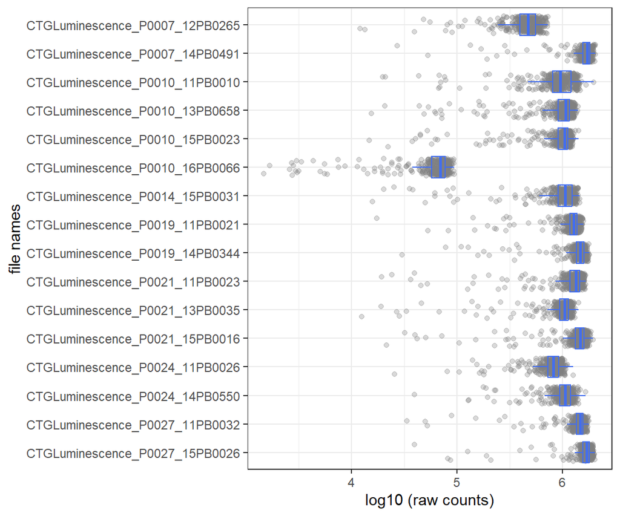

```r
g <- plotRawCount(screenData, ifLog10 = TRUE)
plot(g)
```

The plot identifies the plate “CTGLuminescence_P0010_16PB0066” having a lower overall counts.

## 4.2 Raw count distribution for each well type

If “wellType” column is available, *plotTypeDist()* function can visualize the raw count distribution by well types. The resulting plots can provided a rough check on whether the distribution is reasonable. For instance, negative controls usually have a higher raw counts than the sample wells.

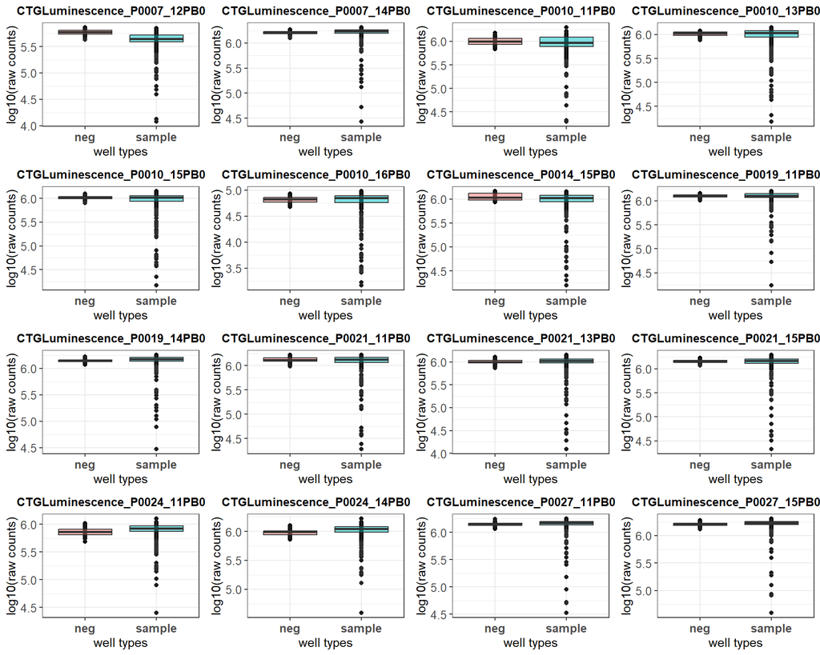

```r
g <- plotTypeDist(screenData, ifLog10 = TRUE)
grid.arrange(grobs = g, ncol = 4)
```

## 4.3 Plate heatmap plot

A more straight forward way to check the screen quality is to plot the signal intensity heatmap for each screen. This can be easily achieved by employing the *platePlot()*. Heatmaps make it easy to identify screen artifacts, such as incubation effects.

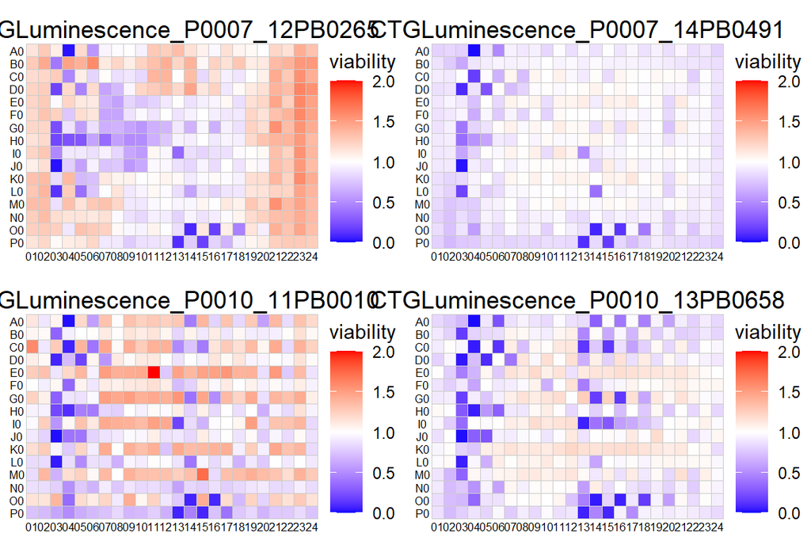

```r
g <- plotPlate(screenData = screenData, plotPlate = "all", plotType = "viability")
grid.arrange(grobs = g[1:4], ncol = 2)
```

*platePlot()* provides heatmap for three types information, namely, ‘layout’, ‘zscore’ and ‘viability’. For *plotType = “viability”*, the normalized inhibition will be used for the heatmap, i.e the *normVal* column must be in the *screenData* object. Alternatively, *platePlot()* visualizes the Z-scores ($Z_i = (x_i - \hat{x})/ sd(x)$), if *plotType = “zscore”* .

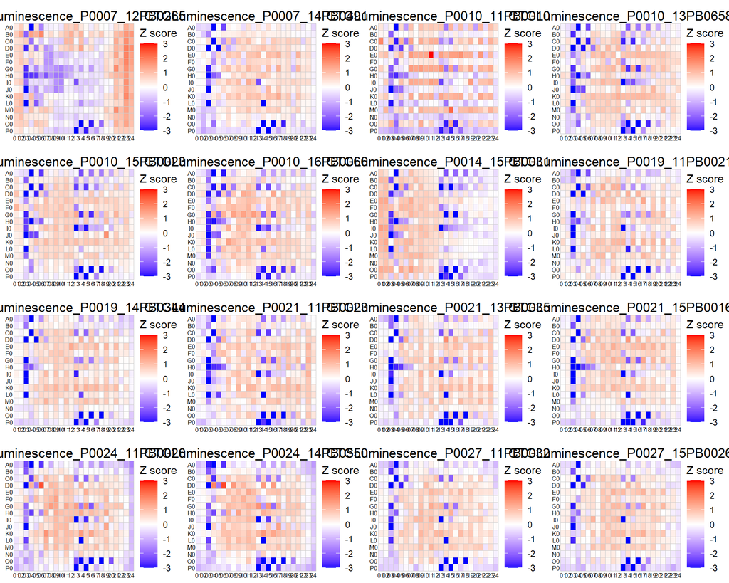

```r
g <- plotPlate(screenData = screenData, plotPlate = "all", plotType = "zscore")
grid.arrange(grobs = g, ncol = 4)
```

The *platePlot* function can also be used to plot the plate layout, by specifying the *type* parameter as “layout”. The resulting plot provides an intuitive representation of the well types and their layout on the plate.

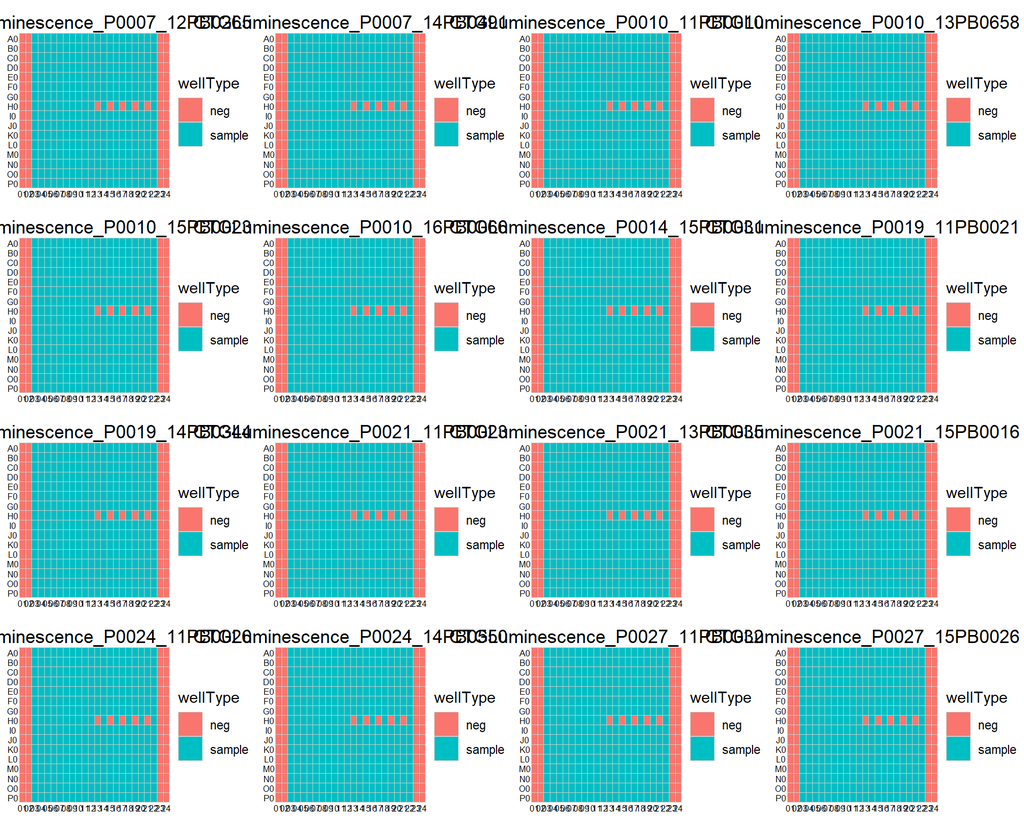

```r
g <- plotPlate(screenData = screenData, plotPlate = "all", plotType = "layout")
grid.arrange(grobs = g, ncol = 4)
```

## 4.4 Automatic screen quality report

An html Rmarkdown report on the screen quality can be automatically generated by using the *makeReport* function. Depend on the annotations included in the screen data tidy table, different quality check items will be included in the report.

```r
makeReport(screenData = screenData, showCode = FALSE, title = "Report for my drug screening project",
    author = "Junyan Lu", ifPlatePlot = TRUE)
```

An html file will be created in *report* folder under the working directory.  
The information on more customizable options can be found at the manual page for *makeReport*

# 5 Adjusting incubation / edge effects

From the plate heatmap plots above, we can observe obvious artifacts. For example, some wells in a certain region show significantly higher or lower signal intensity. This is known as the incubation effect. Those artifacts are typically caused by technical problems, like solvent evaporation, pipetting issues, etc.,. If those problematic wells are only located on the edge of the plate, it is also called the edge effect.

Plates show typical incubation effect and edge effect.

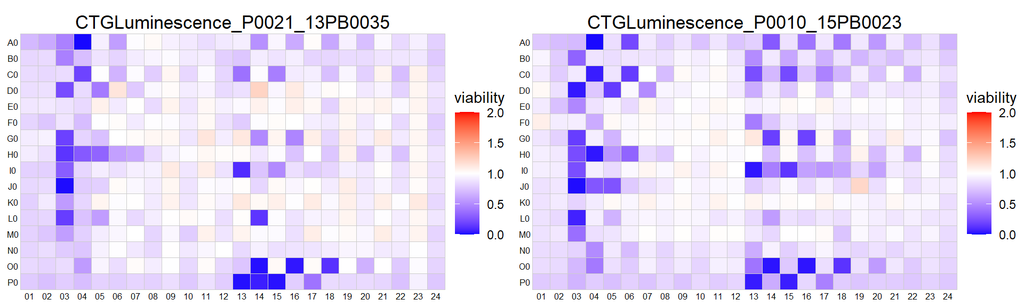

```r
plotPlates <- c("CTGLuminescence_P0021_13PB0035", "CTGLuminescence_P0010_15PB0023")

subScreen <- dplyr::filter(screenData, fileName %in% plotPlates)
g <- plotPlate(subScreen, plotPlate = "all", plotType = "viability")
grid.arrange(grobs = g[c(2, 1)], ncol = 2)
```

The left plate shows the edge effect, where wells located on the edge generally exhibit lower values compared to the middle well. The right plate demonstrates an incubation effect where the left half displays higher values than the right half.

DrugScreenExplorer package provides two functions *fitEdgeEffect* and *correctEdgeEffect* for estimating and correcting incubation effect or edge effect on the plate.

*fitEdgeEffect* provides two methods for estimating the edge effects, namely **loess** and **sigmoid**. The former utilizes the local regression, while the latter uses a 2D-sigmoid model with well locations being the input values.

Typically, we can firstly employ the **fitEdgeEffect()** function to assess the edge effects. After that, **correctEdgeEffect()** can be used to adjusted the inhibition values by removing the estimated edge effects.

```r
subScreen <- fitEdgeEffect(subScreen, method = "loess", useNeg = TRUE, useLowConcentrations = 1,
    span = 1)
```

The estimated incubation effect will be stored in the *edgeFactor* column.  
*useNeg = TRUE* means only negative control wells are used for incubation effect estimation. *useLowConcentrations = 1* means the lowest 1 concentration of the drugs is also considered as the *de facto* negative controls and used for incubation effect estimation. Please refer to the manual page for more explanations of the parameters.

The incubation (edge) effect can be visualized using the *platePlot* function by specifying *plotType = “edgeEffect”*.

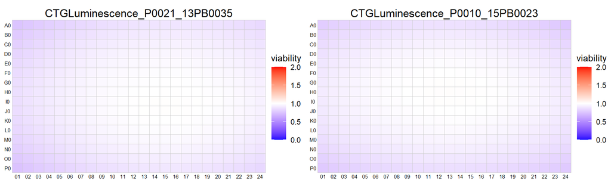

```r
g <- plotPlate(subScreen, plotType = "edgeEffect")
grid.arrange(grobs = g[c(2, 1)], ncol = 2)
```

The edge effects can be removed from the screen plate using *correctEdgeEffect()* function.

```r
subScreen <- correctEdgeEffect(subScreen, correctMethod = "bliss")
```

*correctEdgeEffect()* provides two options for adjusting the edge effects: “bliss” and “linear”. Bliss simply divides the normalized signal intensity by the estimated edge effect intensity. If linear is selected, the correction process will be smoothed by a linear function depends on the original normalized signal intensity. This option is suitable for the situation when the edge effect is very strong and results in instability in the correction process. In this example, the edge effect will be removed by Bliss drug combination model. The corrected value is stored in a new column *normVal.cor*.

Currently, the estimation and correction of incubation effect can only be performed on normalized values The corrected values can also be visualized by *platePlot* function, by specifying *plotType = “viability”* and *ifCorrected = TRUE*

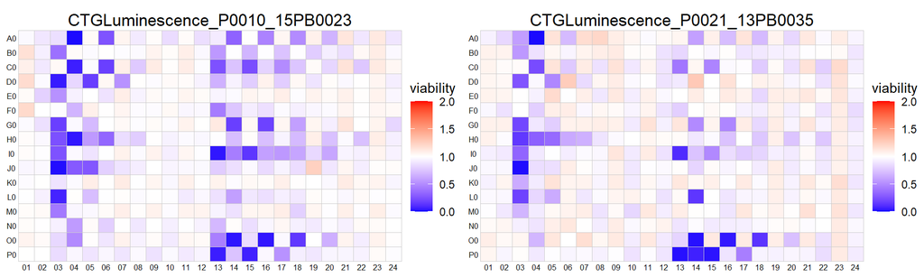

```r
g <- plotPlate(subScreen, plotType = "viability", ifCorrected = TRUE)
grid.arrange(grobs = g, ncol = 2)
```

Now the incubation effect has been largely removed.

**Adjust edge effect for the whole screening data**

```r
screenData <- correctEdgeEffect(screenData, correctMethod = "bliss")
```

Drug effects can be evaluated using the half-maximal inhibitory concentration (IC50). *DrugScreenExplorer* provides the *fitIC50()* function for calculating the IC50. *fitIC50* is developed from *dr4pl* package, where inhibitory concentration is derived by fitting a parameter logistic model.

# 6 Summarisation of drug effect

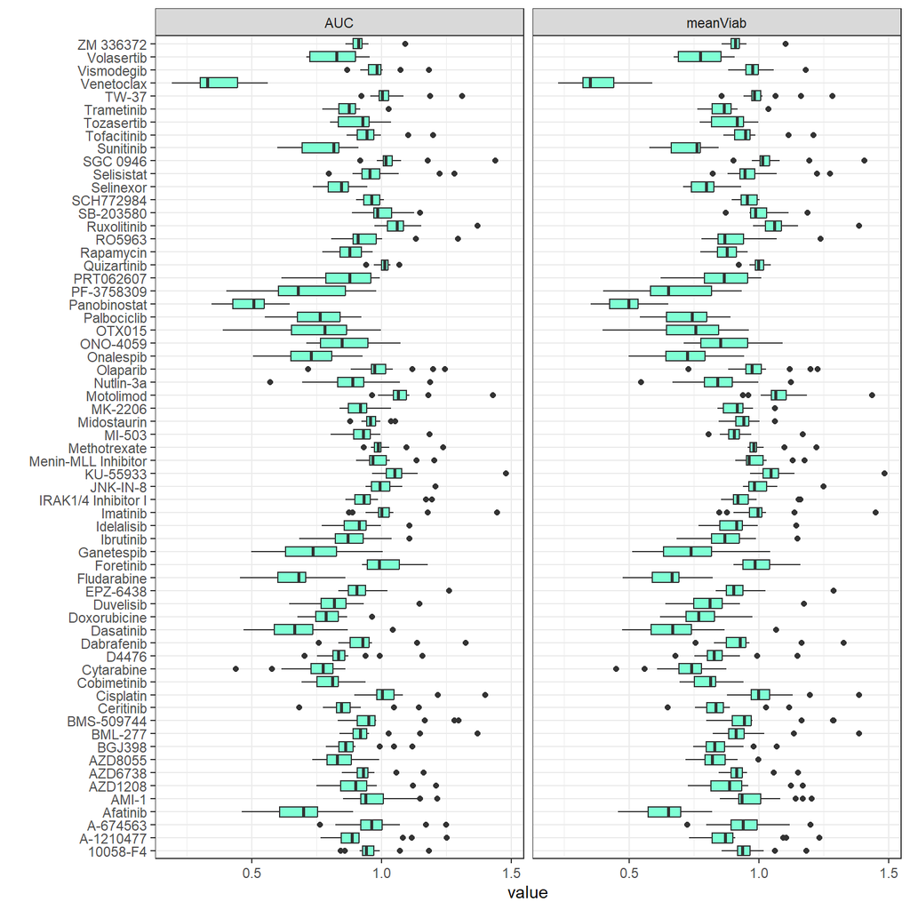

```r
screenData <- summariseScreen(screenData, method = c("average", "AUC"))

sumDat <- screenData %>%
    select(sampleID, drug, meanViab, AUC) %>%
    distinct(sampleID, drug, .keep_all = TRUE) %>%
    pivot_longer(cols = c("meanViab", "AUC"), names_to = "method") %>%
    na.omit()

ggplot(sumDat, aes(x = drug, y = value)) + geom_boxplot(fill = "#7FFFD4") +
    coord_flip() + theme_bw() + xlab("") + facet_grid(~method)
```

# 7 Extension to two-drug combination

*DrugScreenExplorer* allows to summarize the synergy or antagonism effects of two-drug combination. The combination effects can be estimated by two methods between *bliss* or *bayesynergy*.

```r
plateFile <- system.file("testData/plateAnnoCombine/plateAnnoCombine.tsv", package = "DrugScreenExplorer")

wellFile <- system.file("testData/wellAnnoCombine/wellAnnoCombine.tsv", package = "DrugScreenExplorer")

rawFolder <- system.file("testData/rawDataCombine", package = "DrugScreenExplorer")

screenData <- readScreen(rawDir = rawFolder, plateAnnotationFile = plateFile,
    wellAnnotationFile = wellFile, rowRange = c(7, 22), colRange = 2, sep = ",",
    negWell = c("DMSO_DMSO"), posWell = c(), normalization = TRUE)
head(screenData)
```

```
#> # A tibble: 6 × 15
#>   wellID rowID colID   value fileName        sampleID plate cellLine name  drug  concentration drug2
#>   <chr>  <chr> <chr>   <dbl> <chr>           <chr>    <chr> <chr>    <chr> <chr>         <dbl> <chr>
#> 1 A001   A0    01    2591540 P135603_Su-DHL… P135603… Ever… SU-DHL-6 DMSO… DMSO            0   DMSO
#> 2 A002   A0    02    1316330 P135603_Su-DHL… P135603… Ever… SU-DHL-6 Vene… Vene…           3.2 DMSO
#> 3 A003   A0    03    1302440 P135603_Su-DHL… P135603… Ever… SU-DHL-6 Vene… Vene…          16   DMSO
#> 4 A004   A0    04    1331330 P135603_Su-DHL… P135603… Ever… SU-DHL-6 Vene… Vene…          80   DMSO
#> 5 A005   A0    05    1310460 P135603_Su-DHL… P135603… Ever… SU-DHL-6 Vene… Vene…         400   DMSO
#> 6 A006   A0    06    2382690 P135603_Su-DHL… P135603… Ever… SU-DHL-6 DMSO… DMSO            0   Apig…
#> # ℹ 3 more variables: concentration2 <dbl>, wellType <chr>, normVal <dbl>
```

For *bliss* method, the expected combined effects $V_{AB}$ under bliss independence is $ V_{AB}^{bliss} = V_A V_B$, where $V_A$ and $V_B$ are the viability (Grewelle et al., 2021; Zhao et al., 2014).

If observed effect $V_{AB}^{obs}$ is lower than $V_{AB}^{bliss}$, the combination is synergistic; otherwise additive if $V_{AB}^{obs} = V_{AB}^{bliss}$ or antagonistic if $V_{AB}^{obs} > V_{AB}^{bliss}$.

```r
sumScreen <- summariseScreenCombination(screenData, negDrug = "DMSO", method = "bliss")

# remove single drug well
sumScreen %>%
    filter(drug != "DMSO" & drug2 != "DMSO") %>%
    select(drug, concentration, drug2, concentration2, viabObs, viabExp, CI) %>%
    mutate(across(viabObs:CI, ~round(., 3))) %>%
    head()
```

```
#> # A tibble: 6 × 7
#>   drug       concentration drug2    concentration2 viabObs viabExp    CI
#>   <chr>              <dbl> <chr>             <dbl>   <dbl>   <dbl> <dbl>
#> 1 Venetoclax           3.2 Apigenin             10   0.585   0.543 0.042
#> 2 Venetoclax          16   Apigenin            100   0.614   0.495 0.119
#> 3 Venetoclax          80   Apigenin           1000   0.624   0.474 0.15
#> 4 Venetoclax         400   Apigenin          10000   0.621   0.49  0.131
#> 5 Venetoclax           3.2 DCA                  50   0.581   0.443 0.138
#> 6 Venetoclax          16   DCA                 500   0.594   0.498 0.096
```

The **CI** in the table is defined as: $CI = viabObs - viabExp$, where *viabObs* and *viabExp* are Observed viability ($V_{AB}^{obs}$) and Expected viability $V_{AB}^{bliss}$.

- If $CI > 0$: **Antagonism**
- If $CI = 0$: **Additive / Independent**
- If $CI < 0$: **Synergy**

The *bayesynergy* method models drug combination effects using a Bayesian statistical approach. It is designed to distinguish between synergistic, antagonistic, and additive interactions between two drugs.*bayesynergy* provides a flexible and robust framework; however, it is typically more computationally intensive, especially when applied to high-throughput drug screening data.

Of note, the *bayesynergy* package need to be installed manually from *https://github.com/ocbe-uio/bayesynergy* if *bayesynergy* methods is selected to assess the drug combination effects.

# 8 Interactive data exploration using Shiny app

An R Shiny application was developed based on the analysis tools in the *DrugScreenExplorer* package, enabling users of all technical backgrounds to perform comprehensive drug screen analyses through an interactive web interface. The application can be launched using the *runShiny()* or *makeShiny()* functions. For detailed instructions on using the R Shiny application, please refer to the corresponding vignette.

# References

Grewelle, R. E., Wilson, K. L., & Brantley-Sieders, D. M. (2021). Statistical bliss: A novel framework for statistical assessment of drug synergy. *Cancer Research*, *81*(13_Supplement), 262–262.

Zhao, W., Sachsenmeier, K., Zhang, L., Sult, E., Hollingsworth, R. E., & Yang, H. (2014). A new bliss independence model to analyze drug combination data. *Journal of Biomolecular Screening*, *19*(5), 817–821.